# Reproduceable Research - Course Assignment # 1

## Loading and preprocessing the data

1. First we will set the working directory and load the packages

```r
setwd("~/Documents/R Working Directory/Course_5_Reproducable_Research/")
```

2. Next we will load the data and store it into a variable we will call ActivityDataSet; per the assignments instructions we will not exclude the NA items at this time

```r
ActivityDataSet <- read.csv("activity.csv", header=TRUE, sep=",")
head(ActivityDataSet)
```

```
##   steps     date interval
## 1    NA 12-10-01        0
## 2    NA 12-10-01        5
## 3    NA 12-10-01       10
## 4    NA 12-10-01       15
## 5    NA 12-10-01       20
## 6    NA 12-10-01       25
```

### DAILY ACTIVITY ANALYSIS

#### What is mean total number of steps taken per day?

4. We will now find the mean number of steps in the data set - please note I have ignored the NA items

```r
MeanNumberOfSteps <-mean(ActivityDataSet$steps, na.rm=TRUE)
MeanNumberOfSteps
```

```
## [1] 37.3826
```

#### Calculate the total number of steps taken per day

5. We will aggregate the information to a daily basis and find the total, the mean and median

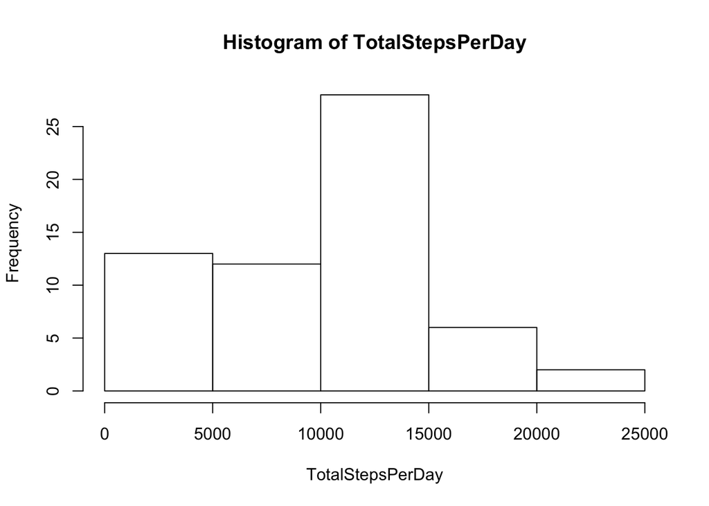

```r
TotalStepsPerDay <-with(ActivityDataSet,tapply(steps,date,sum,na.rm=TRUE))
hist(TotalStepsPerDay)
```

```r
summary(TotalStepsPerDay)
```

```
##    Min. 1st Qu.  Median    Mean 3rd Qu.    Max.
##       0    6778   10400    9354   12810   21190
```

#### Make a histogram of the total number of steps taken each day

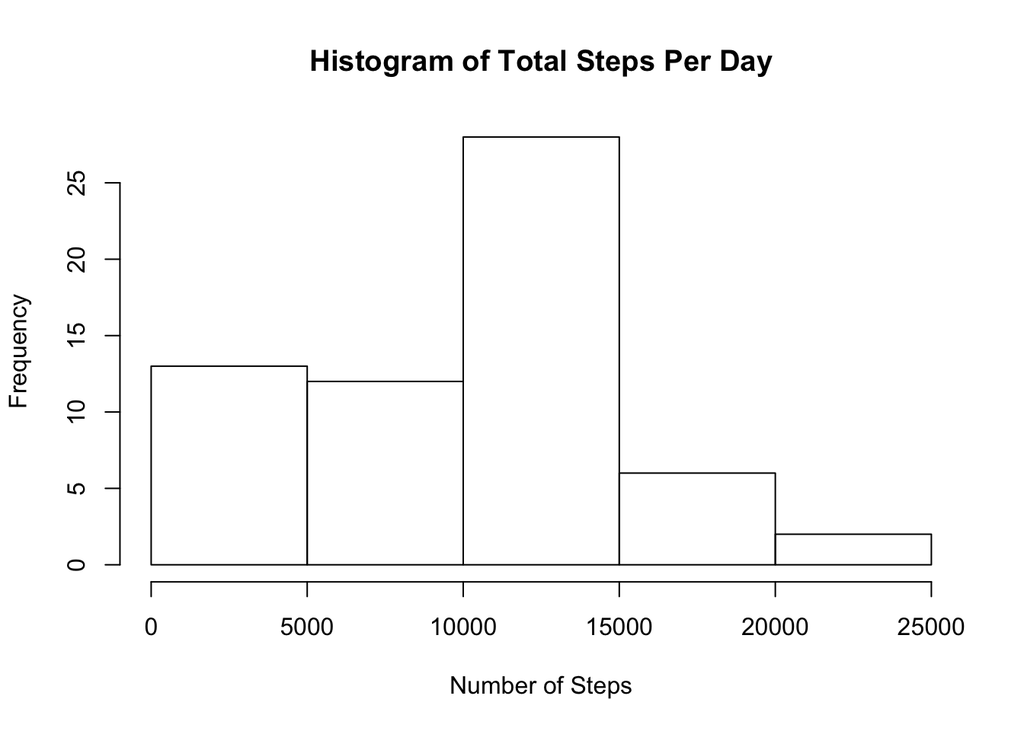

```r
hist(TotalStepsPerDay, xlab = "Number of Steps", ylab="Frequency", main = "Histogram of Total Steps Per Day")
```

#### Calculate and report the mean and median of the total number of steps taken per day

```r
DailyMean <-mean(TotalStepsPerDay)
DailyMedian <-median(TotalStepsPerDay)
summary(TotalStepsPerDay)
```

```
##    Min. 1st Qu.  Median    Mean 3rd Qu.    Max.
##       0    6778   10400    9354   12810   21190
```

#### What is the average daily activity pattern?

The Average daily activity pattern is approximately 9354 Steps per day

#### Make a time series plot (i.e. 𝚝𝚢𝚙𝚎 = “𝚕”) of the 5-minute interval (x-axis) and the average number of steps taken, averaged across all days (y-axis)

6. First we will calculate the average number of steps across all of the days for the specified time periods

```r
AverageStepsPer5minPeriod <-with(ActivityDataSet,tapply(steps,interval,mean,na.rm=TRUE))
```

7. Next we will plot the average steps for each interval across all of the days

[figure not shown]

```r
barplot(AverageStepsPer5minPeriod,
        xlab = "Interval",
        ylab="Average Number of Steps",
        main = "Average Number of Steps Per Interval for the 30 day span"
        )
```

## Imputing missing values

Note that there are a number of days/intervals where there are missing values (coded as 𝙽𝙰). The presence of missing days may introduce bias into some calculations or summaries of the data.

### Calculate and report the total number of missing values in the dataset (i.e. the total number of rows with 𝙽𝙰s)

```r
EmptyRows <-subset(ActivityDataSet,is.na(ActivityDataSet$steps))
nrow(EmptyRows)
```

```
## [1] 2304
```

### Devise a strategy for filling in all of the missing values in the dataset. The strategy does not need to be sophisticated. For example, you could use the mean/median for that day, or the mean for that 5-minute interval, etc.Create a new dataset that is equal to the original dataset but with the missing data filled in.

8. This is an interesting challenge. I will use the mean for the interval (ignoring NAs) as I believe that it will be better fit than the daily mean

```r
IntervalMean <-aggregate(ActivityDataSet$steps,list(ActivityDataSet$interval),mean, na.rm=TRUE)
head(IntervalMean)
```

```
##   Group.1         x
## 1       0 1.7169811
## 2       5 0.3396226
## 3      10 0.1320755
## 4      15 0.1509434
## 5      20 0.0754717
## 6      25 2.0943396
```

After we’ve calculated the Interval mean, we will create a data set that replaces the NA’s with the interval mean

```r
DF2 <- ActivityDataSet
head(DF2)
```

```
##   steps     date interval
## 1    NA 12-10-01        0
## 2    NA 12-10-01        5
## 3    NA 12-10-01       10
## 4    NA 12-10-01       15
## 5    NA 12-10-01       20
## 6    NA 12-10-01       25
```

```r
NAs.a <-is.na(DF2$steps)
head(NAs.a)
```

```
## [1] TRUE TRUE TRUE TRUE TRUE TRUE
```

```r
DF2$steps[NAs.a] <-IntervalMean[match(DF2$interval[NAs.a], IntervalMean$Group.1), ]$x
head(DF2)
```

```
##       steps     date interval
## 1 1.7169811 12-10-01        0
## 2 0.3396226 12-10-01        5
## 3 0.1320755 12-10-01       10
## 4 0.1509434 12-10-01       15
## 5 0.0754717 12-10-01       20
## 6 2.0943396 12-10-01       25
```

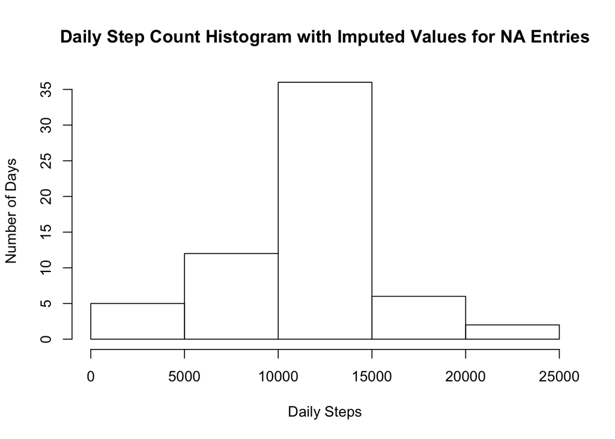

```r
TotalStepsPerDay2 <-with(DF2,tapply(steps,date,sum))
hist(TotalStepsPerDay2, xlab="Daily Steps", ylab="Number of Days", main = "Daily Step Count Histogram with Imputed Values for NA Entries")
```

## Calculate and report the mean and median total number of steps taken per day.

```r
summary(TotalStepsPerDay2)
```

```
##    Min. 1st Qu.  Median    Mean 3rd Qu.    Max.
##      41    9819   10770   10770   12810   21190
```

## Do these values differ from the estimates from the first part of the assignment?

Yes the values differ from the first part of the assignment.

## What is the impact of imputing missing data on the estimates of the total daily number of steps?

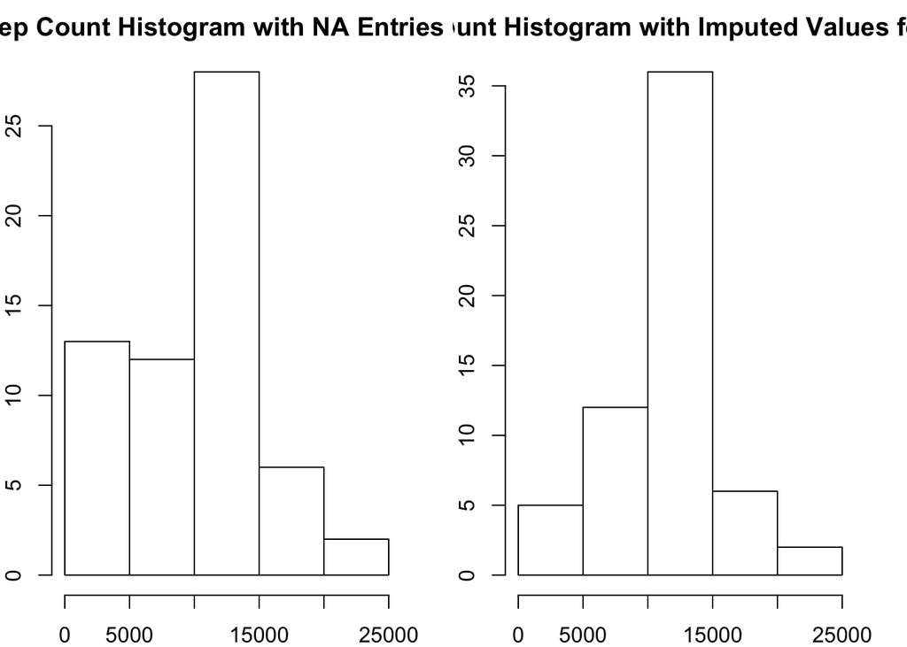

```r
par(mfcol=c(1,2), mar=c(2,2,2,2))

hist(TotalStepsPerDay, xlab="Daily Steps", ylab="Number of Days", main = "Daily Step Count Histogram with NA Entries Omitted")
hist(TotalStepsPerDay2, xlab="Daily Steps", ylab="Number of Days", main = "Daily Step Count Histogram with Imputed Values for NA Entries")
```

### Weekday vs. Weekend Analysis

## Are there differences in activity patterns between weekdays and weekends?

## Create a new factor variable in the dataset with two levels – “weekday” and “weekend” indicating whether a given date is a weekday or weekend day.

```r
DF2$DayOfWeek <- weekdays(as.Date(DF2$date))

for (i in 1:nrow(DF2))
    {
        DF2$WDorWE[i] <-
            if (DF2$DayOfWeek[i] == "Saturday") {"Weekend"
        } else if(DF2$DayOfWeek[i] == "Sunday") {"Weekend"
        } else{"Weekday"}
    }
```

## Make a panel plot containing a time series plot (i.e. 𝚝𝚢𝚙𝚎 = “𝚕”) of the 5-minute interval (x-axis) and the average number of steps taken, averaged across all weekday days or weekend days (y-axis).

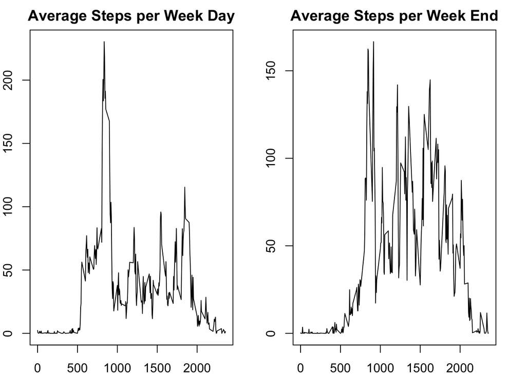

```r
par(mfcol=c(1,2), mar=c(2,2,2,2))
DF3  <-subset(DF2,DF2$WDorWE=="Weekday")
DF4  <-subset(DF2,DF2$WDorWE=="Weekend")
AverageStepsPerWeekday <-aggregate(DF3$steps,list(DF3$interval),mean)
AverageStepsPerWeekend <-aggregate(DF4$steps,list(DF4$interval),mean)

plot(AverageStepsPerWeekday$Group.1, AverageStepsPerWeekday$x, type="l", xlab="Time of Day", ylab="Average Steps Per Day", main="Average Steps per Week Day")
plot(AverageStepsPerWeekend$Group.1, AverageStepsPerWeekend$x, type="l", xlab="Time of Day", ylab="Average Steps Per Day", main="Average Steps per Week End")
```